# Credit Score

ML explainability classification

code

ML

Python, R

Author

Simne Brazzi

Published

October 26, 2024

# 1 Introduction

Create a model capable of estimating the creditworthiness of customers, in order to help the dedicated team understand whether or not to accept a credit card application.

## 1.1 Features

- ID: customer identification number
- CODE_GENDER: gender of the customer
- FLAGOWNCAR: indicator of car ownership
- FLAGOWNREALTY: indicator of house ownership
- CNT_CHILDREN: number of children
- AMTINCOMETOTAL: annual income
- NAMEINCOMETYPE: type of income
- NAMEEDUCATIONTYPE: level of education
- NAMEFAMILYSTATUS: marital status
- NAMEHOUSINGTYPE: type of dwelling
- DAYS_BIRTH: number of days since birth
- DAYS_EMPLOYED: number of days since employment (if positive, indicates the number of days since being unemployed)
- FLAG_MOBIL: indicator for the presence of a mobile phone number
- FLAGWORKPHONE: indicator of the presence of a work phone number
- FLAG_PHONE: indicator of the presence of a telephone number
- FLAG_EMAIL: indicator for the presence of an email address
- OCCUPATION_TYPE: type of occupation
- CNTFAMMEMBERS: number of family members
- TARGET: variable which is worth 1 if the customer has a high creditworthiness (constant payment of installments), 0 otherwise.

If a customer is denied a credit card, the team must be able to give a reason. This means that your model must provide indications that are easy to interpret.

It is a binary classification which needs a good explainability.

# 2 Import

## 2.1 R

```r
library(tidyverse, verbose = FALSE)
library(ggplot2)
library(plotly)
library(reticulate)
library(gt)
library(scales)
library(shapr)

Sys.setenv(RETICULATE_PYTHON = "~/R/blog/posts/credit_score/.venv/bin/python")
```

## 2.2 Python

```python
import pandas as pd
import numpy as np
import matplotlib.pyplot as plt
import pickle
import time
import os

from datetime import date
from dateutil.relativedelta import relativedelta
from sklearn.model_selection import train_test_split, GridSearchCV, RandomizedSearchCV
from sklearn.compose import ColumnTransformer
from sklearn.preprocessing import OneHotEncoder, OrdinalEncoder, StandardScaler, MinMaxScaler, LabelBinarizer
from sklearn.pipeline import Pipeline
from sklearn.tree import DecisionTreeClassifier
from xgboost import XGBClassifier
from xgboost import DMatrix
from sklearn.ensemble import RandomForestClassifier
from sklearn.metrics import classification_report
```

## 2.3 Config class

Listing 1: Config class

```python
class Config():
    def __init__(self):
        """
        Initialize configuration settings for credit scoring model pipeline.
        Sets up file paths, random state, and feature column classifications.
        """
        # Base directory and file paths
        self.path="/Users/simonebrazzi/R/blog/posts/credit_score/"
        self.file="/Users/simonebrazzi/R/blog/posts/credit_score/credit_scoring.csv"
        self.pkl_path="~/R/blog/posts/credit_score/pkl/"

        # Set random state for reproducibility
        self.random_state=42

        # Define feature columns by type
        self.col_binary = ['code_gender', 'flag_own_car', 'flag_own_realty']
        self.col_ordinal = ["name_income_type", "name_education_type", "name_family_status", "name_housing_type", "occupation_type"]
        self.col_numeric = ['cnt_children', 'amt_income_total', 'cnt_fam_members']
        self.features = self.col_binary + self.col_ordinal + self.col_numeric

    def dump_pkl(self, path, model):
        """
        Serialize model to pickle file.
        Args:
            path: Output file path
            model: Model to serialize
        """
        with open(path, "wb") as f:
            pickle.dump(model, f)

    def load_pkl(self, path):
        """
        Load model from pickle file.
        Args:
            path: Input pickle file path
        Returns:
            Deserialized model
        """
        with open(path, "rb") as f:
            model = pickle.load(f)
        return model

    def make_dtc(self):
        """
        Create Decision Tree Classifier pipeline with preprocessing and grid search.
        Returns:
            GridSearchCV object configured for DTC
        """
        # Initialize encoders and scaler
        ohe = OneHotEncoder(drop='if_binary', sparse_output=False)
        oe = OrdinalEncoder().set_output(transform='pandas')
        ss = StandardScaler()

        # Create balanced Decision Tree
        dtc = DecisionTreeClassifier(class_weight="balanced", random_state=config.random_state)

        # Set up preprocessing pipeline
        preprocessor = ColumnTransformer(
            transformers=[
                ("binary_encoder", ohe, config.col_binary),
                ("ordinal_encoder", oe, config.col_ordinal),
                ("standard_scaler", ss, config.col_numeric)
            ],
            remainder='passthrough'
        )

        # Create full pipeline
        pipe_dtc = Pipeline(
            steps=[
                ("preprocessor", preprocessor),
                ("dtc", dtc)
            ]
        )

        # Define hyperparameter search space
        param_grid_dtc = {
            "dtc__criterion": ["gini", "entropy", "log_loss"],
            "dtc__splitter": ["best", "random"],
            "dtc__max_depth": [1, 2, 5, 10, 15]
        }

        # Set up multiple scoring metrics
        scoring = {
            "accuracy": "accuracy",
            "f1": "f1",
            "roc_auc": "roc_auc"
        }

        # Configure grid search
        grid_search_dtc = GridSearchCV(
            estimator=pipe_dtc,
            param_grid=param_grid_dtc,
            cv=7,
            scoring=scoring,
            refit="f1",
            n_jobs=-1
        )

        return grid_search_dtc

    def make_rfc(self):
        """
        Create Random Forest Classifier pipeline with preprocessing and grid search.
        Returns:
            GridSearchCV object configured for RFC
        """
        # Initialize preprocessing components
        ohe = OneHotEncoder(drop='if_binary', sparse_output=False)
        oe = OrdinalEncoder().set_output(transform='pandas')
        ss = StandardScaler()

        # Create balanced Random Forest
        rfc = RandomForestClassifier(class_weight="balanced", random_state=config.random_state)

        # Set up preprocessing pipeline
        preprocessor = ColumnTransformer(
            transformers=[
                ("binary_encoder", ohe, config.col_binary),
                ("ordinal_encoder", oe, config.col_ordinal),
                ("standard_scaler", ss, config.col_numeric)
            ],
            remainder='passthrough'
        )

        # Create full pipeline
        pipe_rfc = Pipeline(
            steps=[
                ("preprocessor", preprocessor),
                ("rfc", rfc)
            ]
        )

        # Define parameter search space
        param_dist_rfc = {
            'rfc__n_estimators': [50, 75, 100],
            'rfc__max_depth': [5, 10, 15],
            'rfc__min_samples_split': [5, 10]
        }

        # Set up scoring metrics
        scoring = {
            "accuracy": "accuracy",
            "f1": "f1",
            "roc_auc": "roc_auc"
        }

        # Configure grid search
        grid_search_rfc = GridSearchCV(
            estimator=pipe_rfc,
            param_grid=param_dist_rfc,
            cv=7,
            scoring=scoring,
            refit="f1",
            n_jobs=-1
        )

        return grid_search_rfc

    def make_xgb(self):
        """
        Create XGBoost Classifier pipeline with preprocessing and randomized search.
        Returns:
            RandomizedSearchCV object configured for XGBoost
        """
        # Initialize preprocessing components
        ohe = OneHotEncoder(drop='if_binary', sparse_output=False)
        oe = OrdinalEncoder().set_output(transform='pandas')
        ss = StandardScaler()

        # Set up preprocessing pipeline
        preprocessor = ColumnTransformer(
            transformers=[
                ("binary_encoder", ohe, config.col_binary),
                ("ordinal_encoder", oe, config.col_ordinal),
                ("standard_scaler", ss, config.col_numeric)
            ],
            remainder='passthrough'
        )

        # Calculate class weight
        scale_pos_weight = len(y[y == 0]) / len(y[y == 1])

        # Create XGBoost classifier
        xgb = XGBClassifier(
            n_jobs=-1,
            enable_categorical=True,
            scale_pos_weight=scale_pos_weight,
            random_state=config.random_state
        )

        # Create full pipeline
        pipe_xgb = Pipeline(
            steps=[
                ("preprocessor", preprocessor),
                ("xgb", xgb)
            ]
        )

        # Define comprehensive parameter search space
        param_dist_xgb = {
            "xgb__n_estimators": [100, 150, 200, 300],
            "xgb__max_depth": [3, 5, 7, 10],
            "xgb__learning_rate": [0.1, 0.01, 0.001, 0.0001],
            "xgb__subsample": [0.7, 0.8, 0.9],
            "xgb__colsample_bytree": [0.7, 0.8, 0.9],
            "xgb__gamma": [0, 0.1],
            "xgb__alpha": [0, 0.1],
            "xgb__lambda": [1, 2]
        }

        # Set up scoring metrics
        scoring = {
            "accuracy": "accuracy",
            "f1": "f1",
            "roc_auc": "roc_auc"
        }

        # Configure randomized search
        random_search_xgb = RandomizedSearchCV(
            estimator=pipe_xgb,
            param_distributions=param_dist_xgb,
            n_iter=30,
            cv=7,
            scoring=scoring,
            refit="f1",
            n_jobs=-1
        )

        return random_search_xgb

# Create global config instance
config = Config()
```

# 3 Dataset

Now we can import the dataset. Having all columns UPPERCASE, I will set all of them as lowercase.

```python
df = pd.read_csv(config.file)
df.columns = df.columns.str.lower()

# df["birthday"] = df.days_birth.map(lambda x : (date.today() + relativedelta(days=x)).strftime("%Y-%m-%d"))
# df["employed"] = df["days_employed"].apply(lambda x: (date.today() + relativedelta(days=x)).strftime("%Y-%m-%d") if x < 0 else "0")
```

# 4 EDA

## 4.1 Target

It is always important to perform an EDA. In this case I am expecting to have less cases of high creditworthiness than low: for my personal knowledge and experience, high creditworthiness clients are not the majority. Also, considering it is a **binary classification**, it is important to be sure if data are balanced to make a better model selection.

```python
value_count = np.unique(df.target, return_counts=True)

var0 = value_count[0][0]
var0_count = value_count[1][0]

var1 = value_count[0][1]
var1_count = value_count[1][1]
```

The variable:

- 0 has 308,705.
- 1 has 29,722.

```r
library(reticulate)

df <- py$df

df_g <- df %>%
  rename(label = target) %>%
  mutate(label = as.factor(label)) %>%
  summarize(
    freq_abs = n(),
    freq_rel = n() / nrow(df),
    .by = label
  )
df_g %>%
  gt() %>%
  fmt_auto() %>%
  cols_width(
    label ~ pct(20),
    freq_abs ~ pct(35),
    freq_rel ~ pct(35)
    ) %>%
  cols_align(
    align = "center",
    columns = c(freq_abs, freq_rel)
  ) %>%
  tab_header(
    title = "Label frequency",
    subtitle = "Absolute and relative frequencies"
  ) %>%
  cols_label(
    label = "Label",
    freq_abs = "Absolute frequency",
    freq_rel = "Relative frequency"
  ) %>%
  tab_options(
    table.width = pct(100)
    )
```

Table 1: Absolute and relative frequencies

Label frequency

Absolute and relative frequencies

| Label | Absolute frequency | Relative frequency |
| --- | --- | --- |
| 0 | 308,705 | 0.912 |
| 1 | 29,722 | 0.088 |

The dataset is **unbalanced** as expected: most of the target are low creditworthiness (0 label). This is important in the training: unbalanced datasets have higher risk of overfitting. If 9 out of 10 observatinos are 0 and you predict 10 times 0, the model has an accuracy of 0.9!

```r
# check for unique values
check_unique_values <- tibble(
  names = names(df),
  values = map(df, ~ .x %>% str_unique() %>% length())
) %>%
  unnest(values)

df %>%
  summary()
```

```
       id          code_gender        flag_own_car       flag_own_realty
 Min.   :5008804   Length:338427      Length:338427      Length:338427
 1st Qu.:5439602   Class :character   Class :character   Class :character
 Median :5878907   Mode  :character   Mode  :character   Mode  :character
 Mean   :5821200
 3rd Qu.:6140206
 Max.   :6841875

  cnt_children     amt_income_total  name_income_type   name_education_type
 Min.   : 0.0000   Min.   :  26100   Length:338427      Length:338427
 1st Qu.: 0.0000   1st Qu.: 121500   Class :character   Class :character
 Median : 0.0000   Median : 162000   Mode  :character   Mode  :character
 Mean   : 0.4289   Mean   : 187654
 3rd Qu.: 1.0000   3rd Qu.: 225000
 Max.   :19.0000   Max.   :6750000

 name_family_status name_housing_type    days_birth     days_employed
 Length:338427      Length:338427      Min.   :-25201   Min.   :-17531
 Class :character   Class :character   1st Qu.:-19482   1st Qu.: -3116
 Mode  :character   Mode  :character   Median :-15622   Median : -1485
                                       Mean   :-15998   Mean   : 60238
                                       3rd Qu.:-12524   3rd Qu.:  -380
                                       Max.   : -7489   Max.   :365243
                                       NA's   :1        NA's   :1
   flag_mobil flag_work_phone    flag_phone       flag_email
 Min.   :1    Min.   :0.0000   Min.   :0.0000   Min.   :0.0000
 1st Qu.:1    1st Qu.:0.0000   1st Qu.:0.0000   1st Qu.:0.0000
 Median :1    Median :0.0000   Median :0.0000   Median :0.0000
 Mean   :1    Mean   :0.2114   Mean   :0.2933   Mean   :0.1052
 3rd Qu.:1    3rd Qu.:0.0000   3rd Qu.:1.0000   3rd Qu.:0.0000
 Max.   :1    Max.   :1.0000   Max.   :1.0000   Max.   :1.0000
 NA's   :1    NA's   :1        NA's   :1        NA's   :1
 occupation_type    cnt_fam_members      target
 Length:338427      Min.   : 1.000   Min.   :0.00000
 Class :character   1st Qu.: 2.000   1st Qu.:0.00000
 Mode  :character   Median : 2.000   Median :0.00000
                    Mean   : 2.197   Mean   :0.08782
                    3rd Qu.: 3.000   3rd Qu.:0.00000
                    Max.   :20.000   Max.   :1.00000
                    NA's   :1
```

```r
g <- ggplot(df_g) +
  geom_bar(aes(x = label, y = freq_abs, fill = label), stat = "identity") +
  xlab("Label") +
  ylab("Absolute frequency") +
  labs(fill = "Label") +
  scale_y_continuous(breaks = scales::breaks_pretty(n = 5)) +
  theme_minimal()
ggplotly(g)
```

[interactive chart not shown]

Figure 1: Creditworthiness absolute frequency

- **0**. stands for **low creditworthiness**.
- **1** stands for **high**.
- Our dataset is strongly unbalanced towards the 0 label.

## 4.2 Features

Lets check the **NA** values in each feature.

```r
df_na <- df %>%
  summarize(across(everything(), ~ sum(is.na(.)))) %>%
  pivot_longer(
    cols = everything(),
    names_to = "columns",
    values_to = "value"
  )
df_na %>%
  gt() %>%
  tab_options(
    table.width = pct(100)
    ) %>%
  cols_align(align = "center") %>%
  cols_label(
    columns = "Columns",
    value = "NA Value"
  ) %>%
  tab_header(
    title = "NA values",
    subtitle = "Number of NA value for each feature"
  ) %>%
  fmt_number(
    columns = c("value"),
    decimals = 2,
    drop_trailing_zeros = TRUE,
    #drop_trailing_dec_mark = FALSE
  )
```

Table 2: Number of NA values for each feature

NA values

Number of NA value for each feature

| Columns | NA Value |
| --- | --- |
| id | 0 |
| code_gender | 0 |
| flag_own_car | 0 |
| flag_own_realty | 0 |
| cnt_children | 0 |
| amt_income_total | 0 |
| name_income_type | 0 |
| name_education_type | 0 |
| name_family_status | 1 |
| name_housing_type | 1 |
| days_birth | 1 |
| days_employed | 1 |
| flag_mobil | 1 |
| flag_work_phone | 1 |
| flag_phone | 1 |
| flag_email | 1 |
| occupation_type | 103,342 |
| cnt_fam_members | 1 |
| target | 0 |

There are 2 interesting things to notice:

#### The column `occupation_type` has lots of NA value. How much in proportion to the total? Should we drop the NAs or keep them?

```r
df %>%
  summarize(
    freq_abs = sum(is.na(occupation_type)),
    freq_rel = sum(is.na(occupation_type)) / nrow(df)
    ) %>%
  gt() %>%
  tab_options(
    table.width = pct(100)
    ) %>%
  cols_align(align = "center") %>%
  cols_label(
    freq_abs = "Absolute Frequency",
    freq_rel = "Relative Frequency"
  ) %>%
  tab_header(
    title = "Absolute and Relative Frequency",
    subtitle = "NA frequency for occupation_type"
  ) %>%
  fmt_number(
    columns = c("freq_abs", "freq_rel"),
    decimals = 2,
    drop_trailing_zeros = TRUE
  )
```

Table 3: NA frequency for occupation_type

Absolute and Relative Frequency

NA frequency for occupation_type

| Absolute Frequency | Relative Frequency |
| --- | --- |
| 103,342 | 0.31 |

30.54% of occupation_type are NA. This could be a big concern: how to handle it? Drop this much could mean losing lots of useful information, while keeping it could lead to impute wrong data, which could be worse.

Lets check the occupation_type labels frequency.

```r
df %>%
  summarise(
    n = n(),
    .by = occupation_type
  ) %>%
  arrange(desc(n)) %>%
  gt() %>%
  tab_options(
    table.width = pct(100)
    ) %>%
  cols_align(align = "center") %>%
  cols_label(
    occupation_type = "Occupation Type",
    n = "Frequency"
  ) %>%
  tab_header(
    title = "Occupation Type Label Frequency"
  ) %>%
  fmt_number(
    columns = c("n"),
    decimals = 2,
    drop_trailing_zeros = TRUE
  )
```

Table 4: Occupation type label frequency

Occupation Type Label Frequency

| Occupation Type | Frequency |
| --- | --- |
| NA | 103,342 |
| Laborers | 60,146 |
| Core staff | 33,527 |
| Sales staff | 31,652 |
| Managers | 27,384 |
| Drivers | 20,020 |
| High skill tech staff | 13,399 |
| Accountants | 12,281 |
| Medicine staff | 10,438 |
| Cooking staff | 6,248 |
| Security staff | 6,218 |
| Cleaning staff | 4,594 |
| Private service staff | 2,787 |
| Low-skill Laborers | 1,714 |
| Secretaries | 1,577 |
| Waiters/barmen staff | 1,245 |
| Realty agents | 852 |
| HR staff | 567 |
| IT staff | 436 |

So here is the situation:

1. we could impute the NA respecting the proportion of the other labels in the dataset or
2. we can drop the NA values.

I want to drop the NA. Even if we are losing a third of the data, we are not making assumption based on the mode. Occupation_type could be a very important feature and doing inference on it is worst then lose some data. Also, we still have 235085, which are plenty enough.

```r
df_occ_type <- df %>%
  filter(!is.na(occupation_type)) %>%
  summarise(
    n = n(),
    .by = occupation_type
  ) %>%
  arrange(desc(n))

# to extend the palette to the number of labels
extended_palette <- colorRampPalette(RColorBrewer::brewer.pal(9, "Purples"))(df_occ_type %>% nrow())

g <- ggplot(df_occ_type) +
  geom_col(aes(x = n, y = reorder(occupation_type, n), fill = reorder(occupation_type, n))) +
  theme_minimal() +
  labs(
    x = "Count",
    y = "Labels",
    title = "Occupation Type Label Frequency"
  ) +
  scale_fill_manual(values = extended_palette)

ggplotly(g)
```

[interactive chart not shown]

Figure 2: Barplot Occupation Type Label frequency

#### There is a NA value in at least all the columns: is it possible it is the same observation?

First of all, we can create a list of the columns name which have only 1 NA, using the `df_na` tibble.

```r
one_cols <- df_na %>%
  filter(value == 1) %>%
  pull(columns)
one_cols
```

```
[1] "name_family_status" "name_housing_type"  "days_birth"
[4] "days_employed"      "flag_mobil"         "flag_work_phone"
[7] "flag_phone"         "flag_email"         "cnt_fam_members"
```

Then, to check multiple OR condition, we can use `if_any()` in R. In this case, we are checking if multiple columns are NA, with the previous filter on only one NA in each column.

```r
library(reticulate)

df %>%
  filter(
    if_any(all_of(one_cols), ~ . %>% is.na())
  ) %>%
  gt()  %>%
  tab_options(
    table.width = pct(100)
    )
```

| id | code_gender | flag_own_car | flag_own_realty | cnt_children | amt_income_total | name_income_type | name_education_type | name_family_status | name_housing_type | days_birth | days_employed | flag_mobil | flag_work_phone | flag_phone | flag_email | occupation_type | cnt_fam_members | target |
| --- | --- | --- | --- | --- | --- | --- | --- | --- | --- | --- | --- | --- | --- | --- | --- | --- | --- | --- |
| 6392180 | F | N | N | 0 | 67500 | Working | Secondary / se | NA | NA | NaN | NaN | NaN | NaN | NaN | NaN | NA | NaN | 0 |

```r
py$id_to_remove <- df %>%
  filter(
    if_any(one_cols, ~ . %>% is.na())
  ) %>%
  pull(id)
```

#### Interesting features

Lets also look at some interesting variables: click on the different tabs to see the frequency table for each of them.

**Note**

Future upgrade will convert this tabset to a Shiny app. I am encountering some difficulties with shinylive, meaning it is not showing the plot.

```r
# features to check
cols <- py$config$features
#
count_results <- map(cols, ~ df %>% filter(!is.na(occupation_type)) %>% count(.data[[.x]]))
names(count_results) <- cols
cols
```

```
 [1] "code_gender"         "flag_own_car"        "flag_own_realty"
 [4] "name_income_type"    "name_education_type" "name_family_status"
 [7] "name_housing_type"   "occupation_type"     "cnt_children"
[10] "amt_income_total"    "cnt_fam_members"
```

**Count children**

```r
count_results$cnt_children %>%
  arrange(desc(n)) %>%
  gt() %>%
  tab_options(
    table.width = pct(100)
    ) %>%
  cols_align(align = "center") %>%
  cols_label(
    cnt_children = "# Children",
    n = "Count"
  ) %>%
  tab_header(
    title = "Count of Number of Children",
  ) %>%
  fmt_number(
    columns = c("n"),
    decimals = 2,
    drop_trailing_zeros = TRUE,
    #drop_trailing_dec_mark = FALSE
  )
```

Table 5: Count of Number of Children

Count of Number of Children

| # Children | Count |
| --- | --- |
| 0 | 148,909 |
| 1 | 56,238 |
| 2 | 26,196 |
| 3 | 3,319 |
| 4 | 300 |
| 5 | 109 |
| 9 | 4 |
| 12 | 4 |
| 14 | 3 |
| 7 | 2 |
| 19 | 1 |

**Education type**

```r
count_results$name_education_type %>%
  arrange(desc(n)) %>%
  gt()  %>%
  tab_options(
    table.width = pct(100)
    ) %>%
  cols_align(align = "center") %>%
  cols_label(
    name_education_type = "Education Type",
    n = "Count"
  ) %>%
  tab_header(
    title = "Count by Education Type",
  ) %>%
  fmt_number(
    columns = c("n"),
    decimals = 2,
    drop_trailing_zeros = TRUE,
    #drop_trailing_dec_mark = FALSE
  )
```

Table 6: Count by Education Type

Count by Education Type

| Education Type | Count |
| --- | --- |
| Secondary / secondary special | 157,822 |
| Higher education | 66,693 |
| Incomplete higher | 8,799 |
| Lower secondary | 1,609 |
| Academic degree | 162 |

**Family status**

```r
count_results$name_family_status %>%
  arrange(desc(n)) %>%
  gt()  %>%
  tab_options(
    table.width = pct(100)
    ) %>%
  cols_align(align = "center") %>%
  cols_label(
    name_family_status = "Family Status",
    n = "Count"
  ) %>%
  tab_header(
    title = "Count by Family Status",
  ) %>%
  fmt_number(
    columns = c("n"),
    decimals = 2,
    drop_trailing_zeros = TRUE,
    #drop_trailing_dec_mark = FALSE
  )
```

Table 7: Count by Family Status

Count by Family Status

| Family Status | Count |
| --- | --- |
| Married | 164,310 |
| Single / not married | 30,551 |
| Civil marriage | 20,968 |
| Separated | 14,108 |
| Widow | 5,148 |

**Housing type**

```r
count_results$name_housing_type %>%
  arrange(desc(n)) %>%
  gt()  %>%
  tab_options(
    table.width = pct(100)
    ) %>%
  cols_align(align = "center") %>%
  cols_label(
    name_housing_type = "House Type",
    n = "Count"
  ) %>%
  tab_header(
    title = "Count by House Type",
  ) %>%
  fmt_number(
    columns = c("n"),
    decimals = 2,
    drop_trailing_zeros = TRUE,
    #drop_trailing_dec_mark = FALSE
  )
```

Table 8: Count by House Type

Count by House Type

| House Type | Count |
| --- | --- |
| House / apartment | 208,980 |
| With parents | 11,938 |
| Municipal apartment | 7,411 |
| Rented apartment | 3,549 |
| Office apartment | 2,270 |
| Co-op apartment | 937 |

**Count family members**

```r
count_results$cnt_fam_members %>%
  arrange(desc(n)) %>%
  gt()  %>%
  tab_options(
    table.width = pct(100)
    ) %>%
  cols_align(align = "center") %>%
  cols_label(
    cnt_fam_members = "Number of Family Members",
    n = "Count"
  ) %>%
  tab_header(
    title = "Count by Number of Family Members",
  ) %>%
  fmt_number(
    columns = c("n"),
    decimals = 2,
    drop_trailing_zeros = TRUE,
    #drop_trailing_dec_mark = FALSE
  )
```

Table 9: Count by Number of Family Members

Count by Number of Family Members

| Number of Family Members | Count |
| --- | --- |
| 2 | 118,852 |
| 3 | 49,232 |
| 1 | 38,902 |
| 4 | 24,556 |
| 5 | 3,138 |
| 6 | 282 |
| 7 | 109 |
| 11 | 4 |
| 14 | 4 |
| 15 | 3 |
| 9 | 2 |
| 20 | 1 |

**Gender**

```r
count_results$code_gender %>%
  arrange(desc(n)) %>%
  gt() %>%
  tab_options(
    table.width = pct(100)
    ) %>%
  cols_align(align = "center") %>%
  cols_label(
    code_gender = "Gender",
    n = "Count"
  ) %>%
  tab_header(
    title = "Count by Gender",
  ) %>%
  fmt_number(
    columns = c("n"),
    decimals = 2,
    drop_trailing_zeros = TRUE,
    #drop_trailing_dec_mark = FALSE
  )
```

Table 10: Count by Gender

Count by Gender

| Gender | Count |
| --- | --- |
| F | 147,505 |
| M | 87,580 |

# 5 Data preparation

```python
df = df[df.id != id_to_remove]
df = df[~df.occupation_type.isna()]
```

# 6 Split

To take into consideration the unbalance and have it also in our split, we can use the `stratify` method.

```python
x = df[config.features]
y = df.target

xtrain, xtest, ytrain, ytest = train_test_split(
    x,
    y,
    test_size = .2,
    stratify = y,
    random_state=config.random_state
)
```

# 7 Models

To address the model **explainability**, we can choose a CART model. They have 2 interesting point for our task:

1. **Explainability**, as already mentioned. This will help us explain the reason of rejection.
2. **Feature selection.** At this [link](https://www.researchgate.net/publication/369355042_A_Comprehensive_Review_of_Feature_Selection_and_Feature_Selection_Stability_in_Machine_Learning) you can find a paper which shows how **embedded method** as the tree models can have the same performance of traditional feature selection method.

It could be also interesting to do a **R**ecursive **F**eature **E**limination. Right now the feature selection is made with personal knowledge to remove some columns before training. The CART model will perform the feature selection, as the paper above explain.

We are going to implement 3 models with an increasingly level of complexity:

1. DecisionTreeClassifier.
2. RandomForestClassifier.
3. XGBoostClassifier.

## 7.1 DecisionTreeClassifier

### 7.1.1 Pipeline

Even if the result of the model are relatively easy to understand, the **hyperparameter tuning** has far too many possibility. This is where `GridSearchCV()` comes handy. Check Listing 1 for more details.

```python
dtc = config.make_dtc()
```

One of the many nice `sklearn` features is the [`Pipeline()`](https://scikit-learn.org/1.5/modules/generated/sklearn.pipeline.Pipeline.html). It has lots of important benefits:

- **Code redundancy and reproducibility** : it is like a recipe you can tune and run without worrying about to put togheter each step in the correct order.
- **Avoid data leakege**: the preprocessing steps applies only to the training dataset.
- **Hyperparameter tuning**: the `Pipeline()` integrates with `GridSearchCV()` and `RandomizedSearchCV()`.
- **Modularity**: it enables tuning the various steps, removing or adding new one.

First, initialize the various preprocessor and the classification model.

The classifier is a `DecisionTreeClassifier()`, which the `GridSearchCV()` will tune.

All of these steps are putted togheter with the `Pipeline()`.

For the binary labels I had to use the `OneHotEncoding(drop="if_binary")`, otherwise other preprocessor would not work with the `ColumnTransformer()`.

### 7.1.2 Fit

```python
dtc_model = dtc.fit(xtrain, ytrain)
```

Check Listing 1 for more details.

### 7.1.3 Pickle

```python
config.dump_pkl(
  path=os.path.expanduser(config.pkl_path) + "dtc_model.pkl",
  model=dtc_model
  )
```

```python
dtc = config.load_pkl(
  path=os.path.expanduser(config.pkl_path) + "dtc_model.pkl"
  )
dtc_model = dtc.best_estimator_
```

### 7.1.4 Classification Report

```python
ypred_dtc = dtc_model.predict(xtest)
cr = classification_report(
  ytest,
  ypred_dtc,
  target_names=['0', '1'],
  digits=4,
  output_dict=True
  )
df_cr_dtc= pd.DataFrame.from_dict(cr).reset_index()
```

```r
library(reticulate)
df_cr <- py$df_cr_dtc %>% dplyr::rename(names = index)
cols <- df_cr %>% colnames()
df_cr %>%
  pivot_longer(
    cols = -names,
    names_to = "metrics",
    values_to = "values"
  ) %>%
  pivot_wider(
    names_from = names,
    values_from = values
  ) %>%
  gt() %>%
  tab_header(
    title = "Confusion Matrix",
    subtitle = "Threshold optimization favoring recall"
  ) %>%
  fmt_number(
    columns = c("precision", "recall", "f1-score", "support"),
    decimals = 2,
    drop_trailing_zeros = TRUE,
    drop_trailing_dec_mark = FALSE
  ) %>%
  cols_align(
    align = "center",
    columns = c("precision", "recall", "f1-score", "support")
  ) %>%
  cols_align(
    align = "left",
    columns = metrics
  ) %>%
  cols_label(
    metrics = "Metrics",
    precision = "Precision",
    recall = "Recall",
    `f1-score` = "F1-Score",
    support = "Support"
  ) %>%
  tab_options(
    table.width = pct(100)
    )
```

Table 11: Classification report DTC

Confusion Matrix

Threshold optimization favoring recall

| Metrics | Precision | Recall | F1-Score | Support |
| --- | --- | --- | --- | --- |
| 0 | 0.99 | 0.74 | 0.85 | 41,986. |
| 1 | 0.3 | 0.94 | 0.46 | 5,031. |
| accuracy | 0.76 | 0.76 | 0.76 | 0.76 |
| macro avg | 0.65 | 0.84 | 0.65 | 47,017. |
| weighted avg | 0.92 | 0.76 | 0.81 | 47,017. |

## 7.2 RandomForestClassifier

### 7.2.1 Pipeline

```python
rfc = config.make_rfc()
```

Check Listing 1 for more details.

### 7.2.2 Fit

```python
tic = time.time()
rfc_model = rfc.fit(xtrain, ytrain)
toc = time.time()
elapsed_time= toc - tic
print(f"Elapsed time: {elapsed_time} seconds")
print(f"Elapsed time: {elapsed_time / 60} minutes")
```

### 7.2.3 Pickle

```python
config.dump_pkl(
  path=os.path.expanduser(config.pkl_path) + "rfc_model.pkl",
  model=rfc_model
  )
```

```python
rfc = config.load_pkl(
  path=os.path.expanduser(config.pkl_path) + "rfc_model.pkl"
  )
rfc_model = rfc.best_estimator_
```

### 7.2.4 Classification

```python
ypred_rfc = rfc_model.predict(xtest)
cr_rfc = classification_report(
  ytest,
  ypred_rfc,
  # target_names=config.labels,
  digits=4,
  output_dict=True
  )
df_cr_rfc = pd.DataFrame.from_dict(cr_rfc).reset_index()
```

```r
library(reticulate)
df_cr <- py$df_cr_rfc %>% dplyr::rename(names = index)
cols <- df_cr %>% colnames()
df_cr %>%
  pivot_longer(
    cols = -names,
    names_to = "metrics",
    values_to = "values"
  ) %>%
  pivot_wider(
    names_from = names,
    values_from = values
  ) %>%
  gt() %>%
  tab_header(
    title = "Confusion Matrix",
    subtitle = "Threshold optimization favoring recall"
  ) %>%
  fmt_number(
    columns = c("precision", "recall", "f1-score", "support"),
    decimals = 2,
    drop_trailing_zeros = TRUE,
    drop_trailing_dec_mark = FALSE
  ) %>%
  cols_align(
    align = "center",
    columns = c("precision", "recall", "f1-score", "support")
  ) %>%
  cols_align(
    align = "left",
    columns = metrics
  ) %>%
  cols_label(
    metrics = "Metrics",
    precision = "Precision",
    recall = "Recall",
    `f1-score` = "F1-Score",
    support = "Support"
  ) %>%
  tab_options(
    table.width = pct(100)
    )
```

Table 12: Classification report RFC

Confusion Matrix

Threshold optimization favoring recall

| Metrics | Precision | Recall | F1-Score | Support |
| --- | --- | --- | --- | --- |
| 0 | 0.99 | 0.77 | 0.86 | 41,986. |
| 1 | 0.33 | 0.95 | 0.49 | 5,031. |
| accuracy | 0.79 | 0.79 | 0.79 | 0.79 |
| macro avg | 0.66 | 0.86 | 0.68 | 47,017. |
| weighted avg | 0.92 | 0.79 | 0.82 | 47,017. |

## 7.3 XGBoostClassifier

### 7.3.1 Pipeline

```python
xgb = config.make_xgb()
```

Check Listing 1 for more details.

### 7.3.2 Fit

```python
tic = time.time()
xgb_model = xgb.fit(xtrain, ytrain)
toc = time.time()
elapsed_time= toc - tic
print(f"Elapsed time: {elapsed_time} seconds")
print(f"Elapsed time: {elapsed_time / 60} minutes")
```

### 7.3.3 Pickle

```python
config.dump_pkl(
  path=os.path.expanduser(config.pkl_path) + "xgb_model.pkl",
  model=xgb_model
  )
```

```python
xgb = config.load_pkl(
  path=os.path.expanduser(config.pkl_path) + "xgb_model.pkl"
  )
xgb_model = xgb.best_estimator_
```

### 7.3.4 Classification

```python
ypred_xgb = xgb_model.predict(xtest)
cr_xgb = classification_report(
  ytest,
  ypred_xgb,
  # target_names=config.labels,
  digits=4,
  output_dict=True
  )
df_cr_xgb = pd.DataFrame.from_dict(cr_xgb).reset_index()
```

```r
library(reticulate)
df_cr <- py$df_cr_xgb %>% dplyr::rename(names = index)
cols <- df_cr %>% colnames()
df_cr %>%
  pivot_longer(
    cols = -names,
    names_to = "metrics",
    values_to = "values"
  ) %>%
  pivot_wider(
    names_from = names,
    values_from = values
  ) %>%
  gt() %>%
  tab_header(
    title = "Confusion Matrix",
    subtitle = "Threshold optimization favoring recall"
  ) %>%
  fmt_number(
    columns = c("precision", "recall", "f1-score", "support"),
    decimals = 2,
    drop_trailing_zeros = TRUE,
    drop_trailing_dec_mark = FALSE
  ) %>%
  cols_align(
    align = "center",
    columns = c("precision", "recall", "f1-score", "support")
  ) %>%
  cols_align(
    align = "left",
    columns = metrics
  ) %>%
  cols_label(
    metrics = "Metrics",
    precision = "Precision",
    recall = "Recall",
    `f1-score` = "F1-Score",
    support = "Support"
  ) %>%
  tab_options(
    table.width = pct(100)
    )
```

Table 13: Classification report XGB

Confusion Matrix

Threshold optimization favoring recall

| Metrics | Precision | Recall | F1-Score | Support |
| --- | --- | --- | --- | --- |
| 0 | 0.99 | 0.82 | 0.9 | 41,986. |
| 1 | 0.39 | 0.95 | 0.55 | 5,031. |
| accuracy | 0.83 | 0.83 | 0.83 | 0.83 |
| macro avg | 0.69 | 0.89 | 0.72 | 47,017. |
| weighted avg | 0.93 | 0.83 | 0.86 | 47,017. |

# 8 Models comparison

Lets check with a plot the performance of all the models. The AUC ROC makes it possible. It is a plot useful for classification tasks. It plots False vs True Positive Rate.

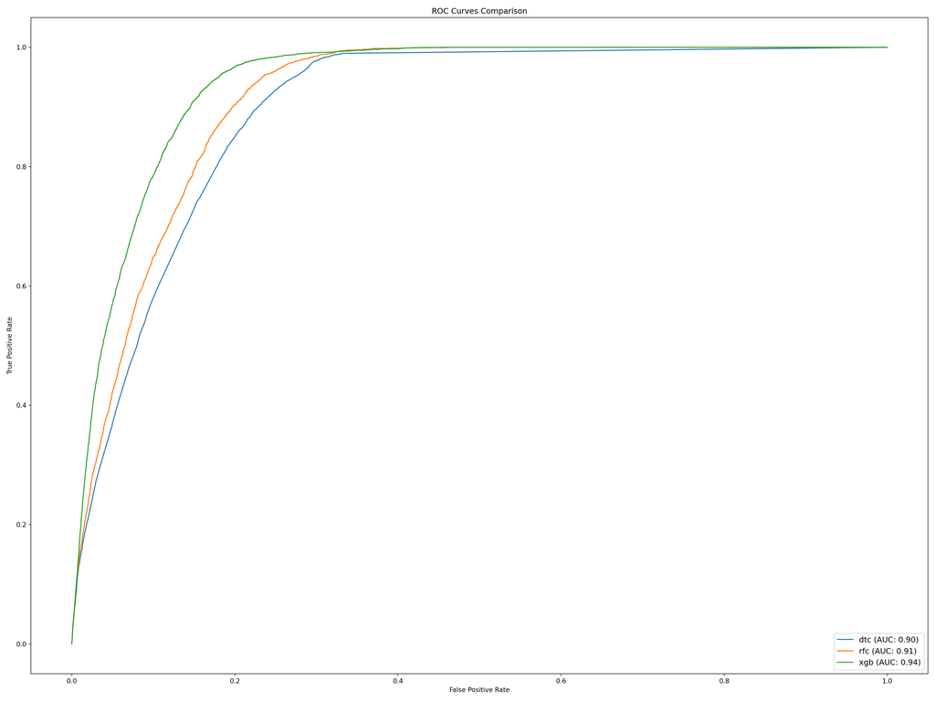

```python
from sklearn.metrics import roc_curve, roc_auc_score
import matplotlib.pyplot as plt

plt.figure(figsize=(20, 15))

model_names = ["dtc", "rfc", "xgb"]
models_ = [dtc_model, rfc_model, xgb_model]
models = zip(model_names, models_)

for name, model in models:
    fpr, tpr, _ = roc_curve(ytest, model.predict_proba(xtest)[:, 1])
    auc_score = roc_auc_score(ytest, model.predict_proba(xtest)[:, 1])
    plt.plot(fpr, tpr, label=f'{name} (AUC: {auc_score:.2f})')
plt.xlabel("False Positive Rate")
plt.ylabel("True Positive Rate")
plt.title("ROC Curves Comparison")
plt.tight_layout()
plt.legend(loc="lower right", fontsize=12)
plt.show()
```

```python
plt.close()
```

From the ROC AUC, the best model is the xgboost, because the **A**rea **U**nder the **C**urve is higher.

# 9 Explainability

What if the model predict a low creditworthiness and the business wants to know why? **Shapley values** make this possible. It comes from cooperative game theory: for more details, check this [link](https://medium.com/the-modern-scientist/what-is-the-shapley-value-8ca624274d5a) and this [link](https://www.sciencedirect.com/science/article/abs/pii/S1574000502030163).

For our purpose, I have found 3 observations we can use. It is also useful to separate the preprocessor and classificator part of the pipeline.

```python
model = xgb_model
preprocessor = model.named_steps["preprocessor"]
clf = model.named_steps["xgb"]
idx = [15454, 1284, 30305]
```

```python
# retain features name
xtrain_processed = preprocessor.transform(xtrain)
xtrain_processed = pd.DataFrame(xtrain_processed, columns=config.features)
# retain features name
xtest_processed = preprocessor.transform(xtest)
xtest_processed = pd.DataFrame(xtest_processed, columns=config.features)
# retain features name
clf.get_booster().feature_names = config.features
# convert to DMatrix
dtrain = DMatrix(xtrain_processed, label=ytrain)
dtest = DMatrix(xtest_processed, label=ytest)
# usefol idxs
idx = [15454, 1284, 30305]

x_processed = preprocessor.transform(x)
```

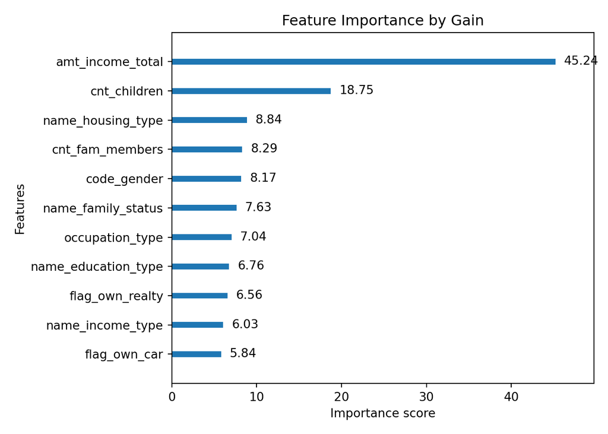

```python
from xgboost import plot_importance

# importance plot
plot_importance(
    booster=clf.get_booster(),
    grid=False,
    importance_type="gain",
    title="Feature Importance by Gain",
    values_format="{v:.2f}"
)
plt.tight_layout()
plt.show()
```

The importance plot tells us the information gain each feature gives to the model prediction. The 3 most important features are also the most logical one:

- Total income amount.
- Number of childrens.
- Type of housing.

Importance provides a **score** that indicates how useful useful each feature is in the construcition of the boosted decision trees. The more an attribute is used to make key decisions with decision trees, the higher its relative importance.

```python
# force plot
plt.figure(figsize=(10, 8))
plot_force = shap.plots.force(
    base_value=explainer.expected_value,
    shap_values=shap_values[idx[0], :],
    # features=None,
    feature_names=config.features,
    # out_names=None,
    # link='identity', # "logit"
    plot_cmap='RdBu',
    matplotlib=True,
    show=True
)
plt.savefig("plot_force.jpeg", dpi=200)

# calculate specific shap explainer for waterfall plot
explainer_ = shap.Explainer(model=xgb_clf)
shap_values_ = explainer(x_processed)
shap_values_.feature_names = config.features
# waterfall plot
shap.plots.waterfall(
    shap_values_[0],
    max_display=len(config.features)
)
plt.savefig("plot_waterfall.jpeg", dpi=200)
# bar plot
shap.plots.bar(
    shap_values_[0],
    max_display=len(config.features)
)
plt.savefig("plot_bar.jpeg", dpi=200)
```

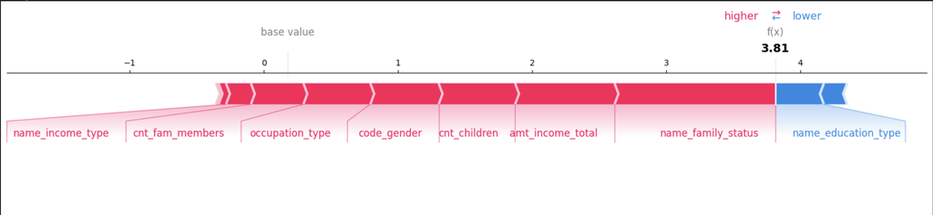

Force plot

The force plot explains the contribution of features to a specific model prediction.

- **Base value** is the model expected output or **mean prediction** over the dataset. It is the prediction the model would make without any specific input features. It is the starting point of the plot.
- **Feature Contributions**. The SHAP values represent how much each feature contributes to the difference between the vase value and the final prediction for a specific observation.
- **Positive contributions**. Features pushing the prediction higher. Shown in red.
- **Negative contributions**. Features pulling the prediction lower. Shown in blue. The magnitude of each bar indicates the size of the feature’s contribution.
- **Final Prediction**. Endpoint of the plot. It is the sum of the base value and all the SHAP values for that observation.

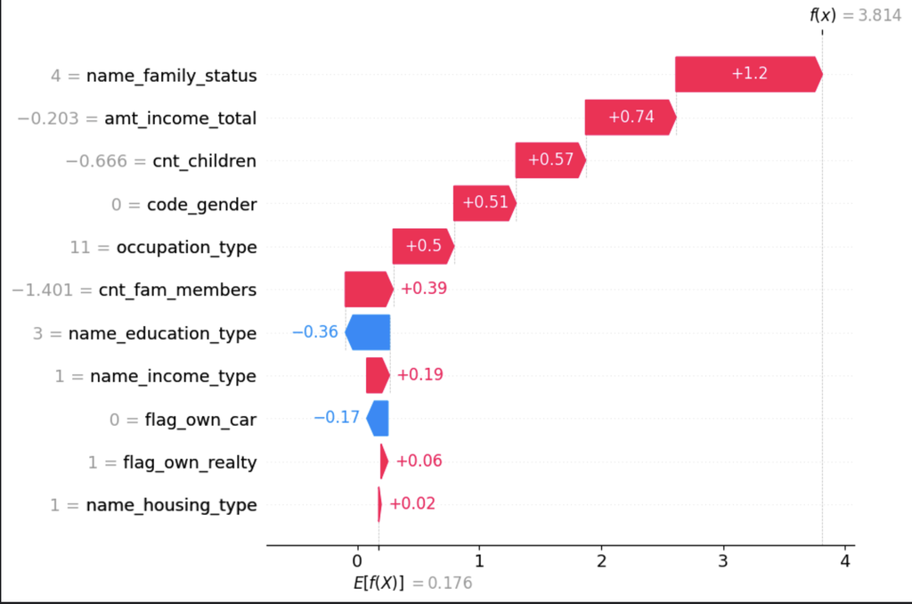

Waterfall plot

Waterfall plots displays explanations for individual predictions. The bottom of a waterfall plot starts as the expected value of the model output, and then each row shows how the positive (red) or negative (blue) contribution of each feature moves the value from the expected model output over the background dataset to the model output for this prediction.

**Important**

Due to venv incompatibilities between shap and other packages, the shap evaluation has been made on Kaggle. The plots are the results of the notebook.